# Text-Classification

```python
from __future__ import print_function
import os
import re
import string
import logging
import itertools
import numpy as np
import pandas as pd
import seaborn as sns
from time import time
from pprint import pprint
import collections

import matplotlib.ticker as ticker
import matplotlib.pyplot as plt
%matplotlib inline
sns.set()# Setting seaborn as default style even if use only matplotlib

import nltk
from nltk import sent_tokenize
from nltk.tokenize import word_tokenize
from nltk.corpus import stopwords

from sklearn import metrics
from sklearn.naive_bayes import MultinomialNB
from sklearn.feature_extraction.text import CountVectorizer
from sklearn.linear_model import SGDClassifier
from sklearn.model_selection import GridSearchCV
from sklearn.pipeline import Pipeline
from nltk.stem.snowball import SnowballStemmer

from sklearn.naive_bayes import BernoulliNB
from sklearn.feature_extraction.text import TfidfVectorizer
from sklearn.linear_model import LogisticRegression
from nltk.stem import WordNetLemmatizer
from sklearn.neighbors import KNeighborsClassifier
from sklearn.ensemble import RandomForestClassifier
```

All the functions we will use in this project:

```python
def generate_target_idx(categories,target):
    """
    Generate train_target_idx ---> target: array, shape [n_samples]. Enumerate categories
    """
    target_names_dict = dict(enumerate(categories))
    target_names_dict = {y:x for x,y in target_names_dict.items()}
    return np.array([target_names_dict[k] for k in target])

def total_number_of_files(filepaths,set):
    """
    count total number of files filepath
    """
    sum = 0
    for i in range(len(filepaths)):
        sum += len(filepaths[i])
    print("Total number of files under "+set+" data set :", sum)


def generate_data(path,filenames, categories):
    """
    Fetch original text files and store into list
    """
    dataList = []
    for i in range(len(filenames)):
        for j in range(len(filenames[i])):
            filePath = path+"//"+categories[i]+"//"+filenames[i][j]
            fileObject = open(filePath, "rt")
            text = fileObject.read()
            dataList.append(text)
            fileObject.close()
    return dataList



def corpus(text):
    """
    NLTK tool help to convert text <str> to words list
    The words will be filtered for punctuation, non alphabetic, and stop word
    The words will be converted to lower case
    """
    # split into words
    from nltk.tokenize import word_tokenize
    tokens = word_tokenize(text)

    # convert to lower case
    tokens = [w.lower() for w in tokens]

    # remove punctuation from each word
    import string
    table = str.maketrans('', '', string.punctuation)
    stripped = [w.translate(table) for w in tokens]

    # remove remaining tokens that are not alphabetic
    words = [word for word in stripped if word.isalpha()]

    # filter out stop words
    from nltk.corpus import stopwords
    stop_words = set(stopwords.words('english'))
    words = [w for w in words if not w in stop_words]
    return words


def generate_data_nltk(dataList):
    """
    Given dataList in list<list> format, return 4 lists
    Parameters
    ----------
    text : list[list[<str>]]
        The text from which to be cleaned and tokenized.

    Returns:
    ----------
    processed_data:  The list of text data with each cleaned by the 6 rules
    corpus_dict: The list of words extracted from the dataList
    file_sentenses_counts: The list of integer, with each equals the
                    lengths of sentences of text element in dataList
    file_words_counts:  The list of integer, with each equals the lengths
                        of words of text element in dataList

    """

    corpus_dict_list = [corpus(text) for text in dataList]
    processed_data = [" ".join(corpus) for corpus in corpus_dict_list]
    corpus_dict = list(itertools.chain.from_iterable(corpus_dict_list))
    file_sentenses_counts = [len(sent_tokenize(text)) for text in dataList]
    file_words_counts = [len(corpus(text)) for text in dataList]

    return(processed_data, corpus_dict, file_sentenses_counts, file_words_counts)

def categories_distplot_compare(targets_str,frequency,
                                targets_test_str,frequency_test):
    """
    Given data and target for two sets, draw the distribution plot on same axis
    """
    fig, (ax1, ax2) = plt.subplots(2, sharex=True,
                                   figsize=(10, 10), dpi= 80,
                                   facecolor='w', edgecolor='k')
    fig.suptitle('Categories Distribution of 20NewGroups for Training & Testing Data')
    plt.xticks(rotation=90)
    plt.xlabel('Categories')
    plt.ylabel('Frequency')
    ax1.bar(targets_str,frequency)
    ax2.bar(targets_test_str,frequency_test)


def draw_dist_and_boxplot(dataset,name):
    """
    Draw Distribution plot & boxplot for given data.
    Original plot together with outliers striped plot
    will be drew

    """
    fig, axes = plt.subplots(2, 2, figsize=(15, 10))
    fig.suptitle('Distribution Plot & Boxplot of '+ name +' Data')

    # Distribution plot with outlier
    sns.distplot(ax=axes[0,0], a=dataset)
    axes[0,0].set_title("Original")

    # Distribution plot without outlier
    datasetTailed = pd.Series( v for v in dataset)
    datasetTailed = datasetTailed[datasetTailed.between(datasetTailed.quantile(.05), datasetTailed.quantile(.95))]
    sns.distplot(ax=axes[0,1], a=datasetTailed)
    axes[0,1].set_title("Without Outliers")

    # Boxplot with outlier
    sns.boxplot(ax=axes[1,0], data=dataset, orient="h",showfliers = True)
    axes[1,0].set_title("Original")

    # Boxplot without outlier
    sns.boxplot(ax=axes[1,1], data=dataset, orient="h",showfliers = False)
    axes[1,1].set_title("Without Outliers")

def strip_newsgroup_header(text):
    """
    Given text in "news" format, strip the headers, by removing everything
    before the first blank line.
    Parameters
    ----------
    text : str
        The text from which to remove the signature block.
    """
    _before, _blankline, after = text.partition('\n\n')
    return after

def strip_newsgroup_footer(text):
    """
    Given text in "news" format, attempt to remove a signature block.
    As a rough heuristic, we assume that signatures are set apart by either
    a blank line or a line made of hyphens, and that it is the last such line
    in the file (disregarding blank lines at the end).
    Parameters
    ----------
    text : str
        The text from which to remove the signature block.
    """
    lines = text.strip().split('\n')
    for line_num in range(len(lines) - 1, -1, -1):
        line = lines[line_num]
        if line.strip().strip('-') == '':
            break

    if line_num > 0:
        return '\n'.join(lines[:line_num])
    else:
        return text

def strip_newsgroup_quoting(text):
    """
    Given text in "news" format, strip lines beginning with the quote
    characters > or |, plus lines that often introduce a quoted section
    (for example, because they contain the string 'writes:'.)
    Parameters
    ----------
    text : str
        The text from which to remove the signature block.
    """
    _QUOTE_RE = re.compile(r'(writes in|writes:|wrote:|says:|said:'
                       r'|^In article|^Quoted from|^\||^>)')
    good_lines = [line for line in text.split('\n')
                  if not _QUOTE_RE.search(line)]
    return '\n'.join(good_lines)

def strip_header_footer_quotes(data):
    """
    Given text will be striped for header, footer, and quotes
    ----------
    text : str
        The text from which to remove the signature block.
    """
    data = [strip_newsgroup_header(text) for text in data]
    data = [strip_newsgroup_footer(text) for text in data]
    data = [strip_newsgroup_quoting(text) for text in data]
    return data


def topKFrequent(words, k):
    """
    Given words list and key parameter K,
    the top K frequent words will be found
    and returned

    Parameters:
    ----------
    words : List of str
    K: integer
    """
        d = collections.defaultdict(int)
        for word in words:
            d[word] += 1
        bucket = [[] for _ in range(len(words) + 1)]
        for key in d:
            bucket[d[key]].append(key)
        res = []
        for i in reversed(range(len(words) + 1)):
            if len(res) >= k:
                break
            if len(bucket[i]) > 0:
                bucket[i].sort()
                if len(bucket[i]) + len(res) <= k:
                    res += bucket[i]
                else:
                    res += bucket[i][:k - len(res)]
        return res


def top_10_popular_words_barplot(top_K_words,orderList):
    """
    Given words list and the unique map of it
    The frequency will be ploted in barplot
    """
    palette = sns.husl_palette(9, s=0.7 )
    dataset = pd.DataFrame({'word': top_K_words})
    ncount = len(dataset)

    plt.figure(figsize=(12,8))
    ax = sns.countplot(x="word", data=dataset, order=orderList)
    plt.title('Most Frequent Words')
    plt.xlabel('Words')

    # Make twin axis
    ax2=ax.twinx()

    # Switch so count axis is on right, frequency on left
    ax2.yaxis.tick_left()
    ax.yaxis.tick_right()

    # Also switch the labels over
    ax.yaxis.set_label_position('right')
    ax2.yaxis.set_label_position('left')

    ax2.set_ylabel('Frequency [%]')

    for p in ax.patches:
        x=p.get_bbox().get_points()[:,0]
        y=p.get_bbox().get_points()[1,1]
        ax.annotate('{:.1f}%'.format(100.*y/ncount), (x.mean(), y),
                ha='center', va='bottom') # set the alignment of the text

    # Use a LinearLocator to ensure the correct number of ticks
    ax.yaxis.set_major_locator(ticker.LinearLocator(11))

    # Fix the frequency range to 0-100
    ax2.set_ylim(0,100)
    ax.set_ylim(0,ncount)

    # And use a MultipleLocator to ensure a tick spacing of 10
    ax2.yaxis.set_major_locator(ticker.MultipleLocator(10))

    # Need to turn the grid on ax2 off, otherwise the gridlines end up on top of the bars
    ax2.grid(None)


def gridSearch(pipeline, parameters, train_data, train_target, test_data, test_target):
    """
    Given train & test data/target, parameter sets,
    best parameters will be found and applied to
    predict the test data
    F1 macro score will be returned as result.
    """
    if __name__ == "__main__":
        # multiprocessing requires the fork to happen in a __main__ protected
        # block

        # find the best parameters for both the feature extraction and the
        # classifier
        grid_search = GridSearchCV(pipeline, parameters, scoring='f1_macro', n_jobs=-1, verbose=1)

#         print("Performing grid search...")
#         print(pipeline, [name for name, _ in pipeline.steps])
#         print("parameters:")
#         pprint(parameters)
#         t0 = time()
        grid_search.fit(train_data, train_target)
#         print("done in %0.3fs" % (time() - t0))
#         print()

#         print("Best score: %0.3f" % grid_search.best_score_)
#         print("Best parameters set:")
        best_parameters = grid_search.best_estimator_.get_params()
#         for param_name in sorted(parameters.keys()):
#             print("\t%s: %r" % (param_name, best_parameters[param_name]))

            # Test Accuracy
#         print("Grid Search Best Parameters Test F1 score:")
#         print(grid_search.best_estimator_.score(test_data, test_target))
        return grid_search.best_estimator_.score(test_data, test_target)
```

## Data Exploration

The training dataset contains 11084 files with 20 categories, which are the lables we are going to predict for test dataset. There are 7761 files in the testing dataset.Both datasets contianed the same categores.

```python
## Read data from local drive
train_path = "C://Users//yueQiu//Desktop//data//data//data//train"
test_path = "C://Users//yueQiu//Desktop//data//data//data//test"

## Fetch categories for train & test
train_categories = os.listdir(train_path)
test_categories = os.listdir(train_path)
pprint(list(train_categories))
# pprint(list(test_categories))

## Find total number of files for train & test
train_filenames_2DList = []
test_filenames_2DList = []
for cate in train_categories:
    train_filenames_2DList.append(os.listdir(train_path+'/'+cate))

for cate in test_categories:
    test_filenames_2DList.append(os.listdir(test_path+'/'+cate))

total_number_of_files(train_filenames_2DList,"train")
total_number_of_files(test_filenames_2DList,"test")
```

```
['alt.atheism',
 'comp.graphics',
 'comp.os.ms-windows.misc',
 'comp.sys.ibm.pc.hardware',
 'comp.sys.mac.hardware',
 'comp.windows.x',
 'misc.forsale',
 'rec.autos',
 'rec.motorcycles',
 'rec.sport.baseball',
 'rec.sport.hockey',
 'sci.crypt',
 'sci.electronics',
 'sci.med',
 'sci.space',
 'soc.religion.christian',
 'talk.politics.guns',
 'talk.politics.mideast',
 'talk.politics.misc',
 'talk.religion.misc']
Total number of files under train data set : 11084
Total number of files under test data set : 7761
```

Here is the frequency table for the categories in train set:

```python
# Finding frequency of each category in training set
# train_target: list, shape[n_sample]. The names of target classes.
train_target = []
for i in range(len(train_filenames_2DList)):
    for j in range(len(train_filenames_2DList[i])):
        train_target.append(train_categories[i])

train_target = np.array(train_target)
targets, frequency = np.unique(train_target, return_counts=True)
targets, frequency

targets_str = np.array(train_categories)
pprint(list(zip(targets_str, frequency)))
```

```
[('alt.atheism', 480),
 ('comp.graphics', 585),
 ('comp.os.ms-windows.misc', 591),
 ('comp.sys.ibm.pc.hardware', 590),
 ('comp.sys.mac.hardware', 578),
 ('comp.windows.x', 593),
 ('misc.forsale', 585),
 ('rec.autos', 593),
 ('rec.motorcycles', 598),
 ('rec.sport.baseball', 597),
 ('rec.sport.hockey', 172),
 ('sci.crypt', 595),
 ('sci.electronics', 591),
 ('sci.med', 792),
 ('sci.space', 593),
 ('soc.religion.christian', 599),
 ('talk.politics.guns', 546),
 ('talk.politics.mideast', 564),
 ('talk.politics.misc', 465),
 ('talk.religion.misc', 377)]
```

Generate target list for both train and test sets:

```python
# Finding frequency of each category in test set
# test_target: list, shape[n_sample]. The names of target classes.
test_target = []
for i in range(len(test_filenames_2DList)):
    for j in range(len(test_filenames_2DList[i])):
        test_target.append(test_categories[i])

test_target = np.array(test_target)
targets_test, frequency_test = np.unique(test_target, return_counts=True)
targets_test, frequency_test

targets_test_str = np.array(test_categories)
# pprint(list(zip(targets_test_str, frequency_test)))

# Enumerate target categories
train_target_idx = generate_target_idx(train_categories,train_target)
test_target_idx = generate_target_idx(test_categories,test_target)
print(train_target_idx)
```

```
[ 0  0  0 ... 19 19 19]
```

To inspect the categories distributions for both train and test sets to detect whether there exist imbalanced data set problem:

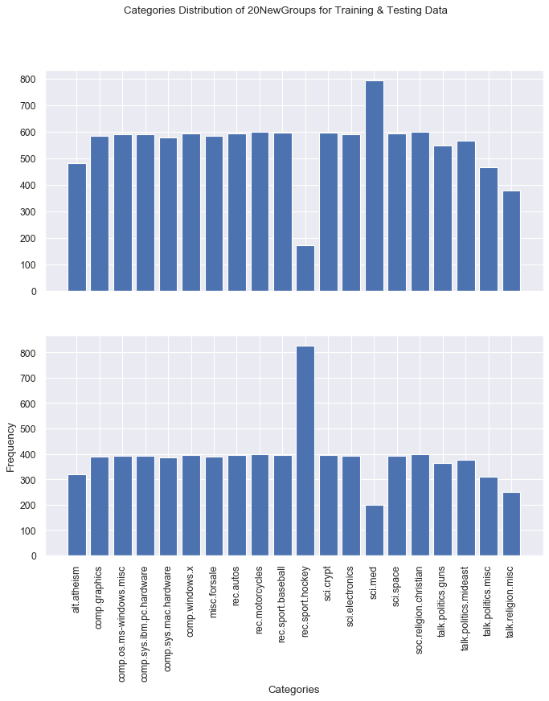

```python
# Draw barplots for the distribution of categories for train & test set
categories_distplot_compare(targets_str,frequency,targets_test_str,frequency_test)
```

From now on, we want to dig more into the text files, to analyze their sizes from #lines, #words, #sentences. Here we generate the information we want using build in Python String, NLTK, and Textblob.

## Data Preprocessing

Here we apply 7 strategies to clean the text files:

1. Remove header, footer, quotes
2. Load the raw text.
3. Split into tokens.
4. Convert to lowercase.
5. Remove punctuation from each token.
6. Filter out remaining tokens that are not alphabetic.
7. Filter out tokens that are stop words

Store the text data into train_data, each element is the text content of one text file.

```python
# train_data ---> dataList: List, [n_sampple]. <class 'str'>
train_data = generate_data(train_path,train_filenames_2DList,train_categories)
test_data = generate_data(test_path,test_filenames_2DList,test_categories)
print(len(train_data))

# Text preprocessing step 1. Remove header, footer, quotes from each text files
train_data = strip_header_footer_quotes(train_data)
test_data = strip_header_footer_quotes(test_data)
```

```
11084
```

```python
# Text preprocessing step 2-7. Remove header, footer, quotes from each text files
train_data, train_corpus_dict, train_file_sentenses, train_file_words_nltk = generate_data_nltk(train_data)
test_data, test_corpus_dict, test_file_sentenses, test_file_words_nltk = generate_data_nltk(test_data)

print(len(train_data))
```

```
11084
```

### Outliers

Let's define the size of each file in two dimensions:

1. The number of sentenses
2. The number of words

Four distribution plots are drew for both train and test sets for the two dimensions. From the below chatrs, we found both the train and test sets are highly skewded for the features: number of sentenses and the number of words per file.

For train set, with #sentenses's median is around 6 while the maximum number is over 800, and in test set, the median for #sentenses is around 5 while the maximum number is over 1200.

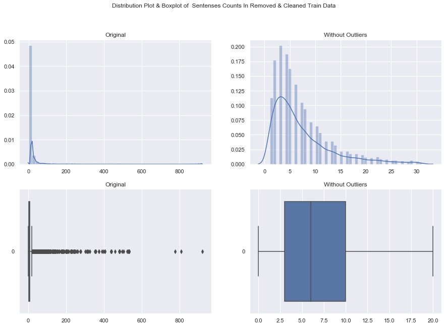

```python
draw_dist_and_boxplot(train_file_sentenses," Sentenses Counts In Removed & Cleaned Train")
```

We can either choose to delete those extreamly long files or to leave them along. The trade-off here is the loss of information and the bias introduced by outliers.

```python
datasetTailed = pd.Series( v for v in train_file_sentenses)
datasetTailed = datasetTailed[datasetTailed.between(datasetTailed.quantile(.05), datasetTailed.quantile(.95))]
a = len(train_file_sentenses)
b = len(datasetTailed)
print("The percentage of information lose while deleting outliers: ")
print((a-b)/a*100,"%")
```

```
The percentage of information lose while deleting outliers:
7.605557560447491 %
```

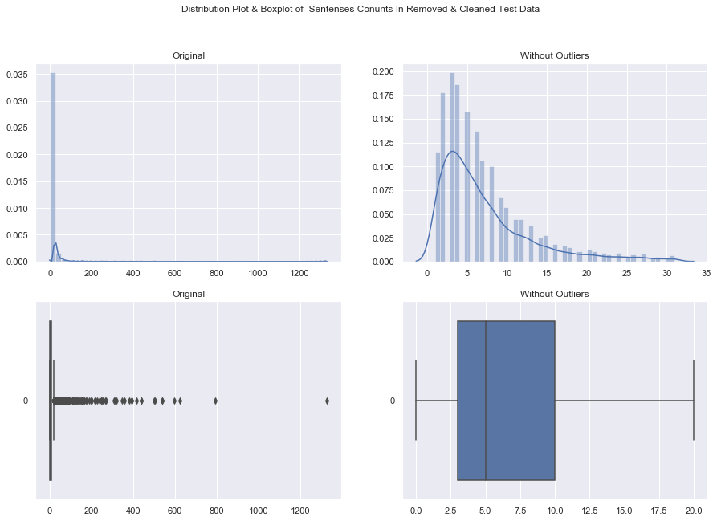

```python
draw_dist_and_boxplot(test_file_sentenses," Sentenses Conunts In Removed & Cleaned Test")
```

```python
datasetTailed = pd.Series( v for v in train_file_words_nltk)
datasetTailed = datasetTailed[datasetTailed.between(datasetTailed.quantile(.05), datasetTailed.quantile(.95))]
a = len(train_file_words_nltk)
b = len(datasetTailed)
print("The percentage of information lose while deleting outliers: ")
print((a-b)/a*100,"%")
```

```
The percentage of information lose while deleting outliers:
9.364850234572357 %
```

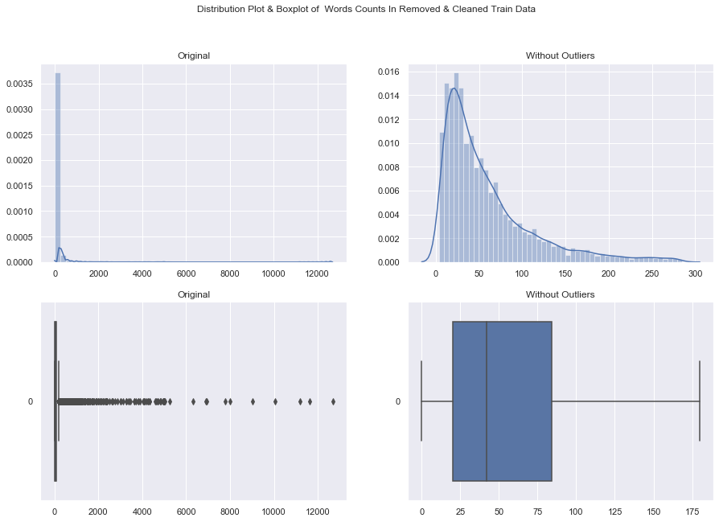

```python
draw_dist_and_boxplot(train_file_words_nltk," Words Counts In Removed & Cleaned Train")
```

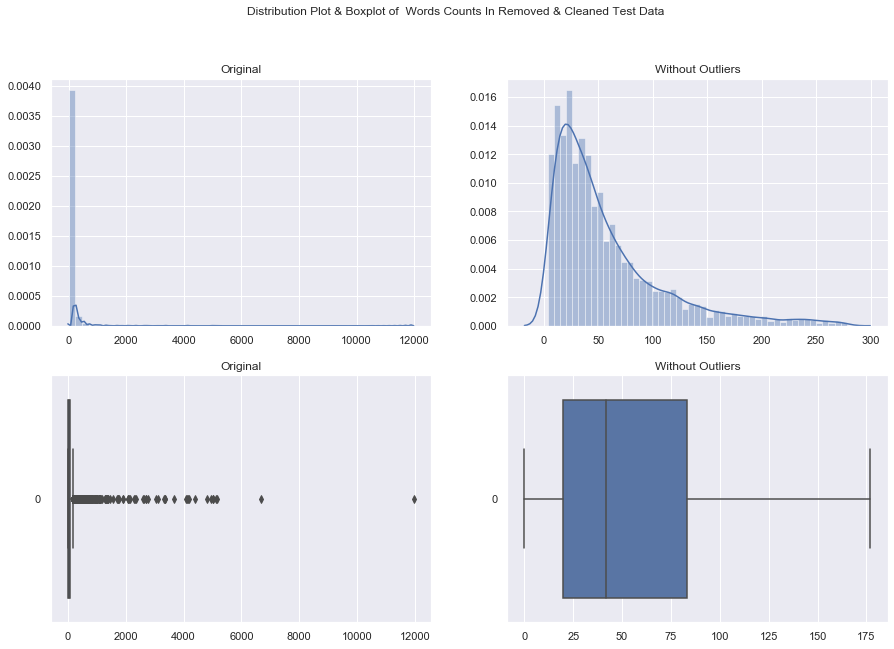

```python
draw_dist_and_boxplot(test_file_words_nltk," Words Counts In Removed & Cleaned Test")
```

### Top10 Popular Words

```python
# Find the 10 most popular words in train set
top_K_word_dict = topKFrequent(train_corpus_dict,10)
print("Top 10 popular word:")
print(top_K_word_dict)

top_K_words = [value for value in train_corpus_dict if value in top_K_word_dict]
```

```
Top 10 popular word:
['ax', 'nt', 'would', 'one', 'x', 'max', 'people', 'like', 'q', 'get']
```

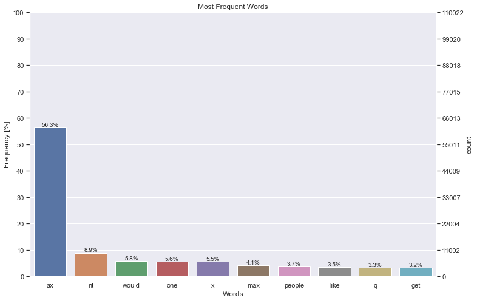

```python
# Draw the distribution plot for 10 most popular words in train set
top_10_popular_words_barplot(top_K_words,top_K_word_dict)
```

Amoung the top 10 popular words we founded in train set, the word "ax" is significantly outstanding.

## Extracting features from text files

Now let's talk about converting text file to numerical vectores for statistical analysis. There are several methods to achieve the goal.

### Descriptive Features

According to **bag of words model**, we can find the **descriptive features** for each file. To do that, we segment each text file into words (for English splitting by space), and count number of times each word occurs in each document and finally assign each word an integer id. Each unique word in our dictionary will correspond to a feature. However, such method has the problem that it will give more weightage to longer documents than shorter documents.

Here by doing `count_vect.fit_transform(train_data)`, we are learning the vocabulary dictionary and it returns a Document-Term matrix. `[n_samples, n_features]`.

```python
from sklearn.feature_extraction.text import CountVectorizer
count_vect = CountVectorizer()
count_vector = count_vect.fit_transform(train_data)
count_vector.shape
```

```
(11084, 79010)
```

### Term Frequencies

To avoid this, we can use **TF** (TF - Term Frequencies) i.e. #count(word) / #Total words, in each file. This will generate a sparse feature space with 79010 freatures but less than .1% non-zero features.

### Term Frequency Times Inverse Document Frequency

Finally, we can even reduce the weightage of more common words like (the, is, an etc.) which occurs in all document. This is called as **TF-IDF** (Term Frequency times inverse document frequency). This will generate a sparse feature space with 79010 freatures but less than .1% non-zero features.

We can achieve both using below lines of code:

```python
vectorizer = TfidfVectorizer()
vectors = vectorizer.fit_transform(train_data)
vectors.shape
```

```
(11084, 79010)
```

The extracted TF-IDF vectors are very sparse, with an average of 66 non-zero components by sample in a more than 79010-dimensional space (less than 0.8% non-zero features):

```python
vectors.nnz / float(vectors.shape[0])
```

```
65.67114760014435
```

```python
vectors.nnz / float(vectors.shape[0]) / vectors.shape[1]
```

```
0.0008311751373262163
```

## Modeling

### Pipeline & GridSearch

We combine the different vectorizer together with the models to generate different pipelines.

1. Neither stemming nor lemmatization
2. Stemming: reduce inflected (or sometimes derived) words to their word stem, base or root form.
3. Lemmatization:

Then, we can decide the terms in TF-IDF Vectorizer to be

1. unigrams (single word)
2. unigrams and bigrams

Finally, we have 3 classifiers:

1. Native Bayes
2. SGD
3. Logistic Regression

Hence we can combine all these factors to generate 18 pipelines:

1. Neither stemming nor lemmatization
   - Group 1: TF-IDF unigrams NB, SGD,LG
   - Group 2: TF-IDF unigrams & bigrams NB, SGD,LG
2. Stemming
   - Group 3: TF-IDF unigrams NB, SGD,LG
   - Group 4: TF-IDF unigrams & bigrams NB, SGD,LG
3. Lemmatization
   - Group 5: TF-IDF unigrams NB, SGD,LG
   - Group 6: TF-IDF unigrams & bigrams NB, SGD,LG

We will apply GridSearch to find the optimize parameters for some pipelines.

#### No use of stemming or lemmatization

##### TF-IDF unigrams

```python
# Design pipelines for Group 1
SGD_pipeline = Pipeline([
    ('vect', TfidfVectorizer(stop_words='english', sublinear_tf=True)),
    ('clf', SGDClassifier()),
])

NB_pipeline = Pipeline([
    ('vect', TfidfVectorizer(stop_words='english', sublinear_tf=True)),
    ('clf',MultinomialNB()),
])

LG_pipeline = Pipeline([
    ('vect', TfidfVectorizer(stop_words='english', sublinear_tf=True)),
    ('clf',LogisticRegression()),
])
```

```python
# Define parameter sets
SGD_parameters = {
    'vect__max_df': (0.5, 0.75, 1.0),
    'clf__alpha': (0.00001, 0.000001)
}

NB_parameters = {
    'vect__max_df': (0.5, 0.75, 1.0),
    'clf__alpha': (0.00001, 0.000001)
}

LG_parameters = {
    'clf__penalty': ('l1', 'l2')
}
```

Run grid search on each pipeline to find the best parameters and at the same time return the predictive F1-score on test data.

```python
gridSearch(SGD_pipeline, SGD_parameters, train_data, train_target_idx, test_data, test_target_idx)
```

[output not shown]

```python
gridSearch(NB_pipeline, NB_parameters, train_data, train_target_idx, test_data, test_target_idx)
```

[output not shown]

```python
gridSearch(LG_pipeline, LG_parameters, train_data, train_target_idx, test_data, test_target_idx)
```

[output not shown]

```python
# Design pipelines for Group 2
SGD_pipeline = Pipeline([
    ('vect', TfidfVectorizer(stop_words='english', ngram_range = (1,2), binary = True, sublinear_tf=True)),
    ('clf', SGDClassifier()),
])

NB_pipeline = Pipeline([
    ('vect', TfidfVectorizer(stop_words='english', ngram_range = (1,2), binary = True, sublinear_tf=True)),
    ('clf',MultinomialNB()),
])

LG_pipeline = Pipeline([
    ('vect', TfidfVectorizer(stop_words='english', ngram_range = (1,2), binary = True, sublinear_tf=True)),
    ('clf',LogisticRegression()),
])
```

```python
gridSearch(SGD_pipeline, SGD_parameters, train_data, train_target_idx, test_data, test_target_idx)
```

[output not shown]

```python
gridSearch(NB_pipeline, NB_parameters, train_data, train_target_idx, test_data, test_target_idx)
```

[output not shown]

```python
gridSearch(LG_pipeline, LG_parameters, train_data, train_target_idx, test_data, test_target_idx)
```

[output not shown]

#### Group 3 pipelines & F1-score

```python
# Design pipelins for Group 3
stemmer = SnowballStemmer('english', ignore_stopwords=True)
class StemmedTfidfVectorizer(TfidfVectorizer):
    def __init__(self, stemmer, *args, **kwargs):
        super(StemmedTfidfVectorizer, self).__init__(*args, **kwargs)
        self.stemmer = stemmer
    def build_analyzer(self):
        analyzer = super(StemmedTfidfVectorizer, self).build_analyzer()
        return lambda doc: (self.stemmer.stem(word) for word in analyzer(doc.replace('\n', ' ')))

# StemmedTfidfVectorizer(stemmer=stemmer,stop_words='english', sublinear_tf=True)
SGD_pipeline = Pipeline([
    ('vect', StemmedTfidfVectorizer(stemmer=stemmer,stop_words='english', sublinear_tf=True)    ),
    ('clf', SGDClassifier()),
])

NB_pipeline = Pipeline([
    ('vect', StemmedTfidfVectorizer(stemmer=stemmer,stop_words='english', sublinear_tf=True)    ),
    ('clf',MultinomialNB()),
])

LG_pipeline = Pipeline([
    ('vect', StemmedTfidfVectorizer(stemmer=stemmer,stop_words='english', sublinear_tf=True)    ),
    ('clf',LogisticRegression()),
])
```

```python
SGD_pipeline.fit(train_data, train_target_idx)
print(SGD_pipeline.score(test_data, test_target_idx))

NB_pipeline.fit(train_data, train_target_idx)
print(NB_pipeline.score(test_data, test_target_idx))

LG_pipeline.fit(train_data, train_target_idx)
print(LG_pipeline.score(test_data, test_target_idx))
```

[output not shown]

#### Group 4 pipelines & F1-score

```python
SGD_pipeline = Pipeline([
    ('vect', StemmedTfidfVectorizer(stemmer=stemmer, stop_words='english', ngram_range = (1,2), binary = True, sublinear_tf=True)),
    ('clf', SGDClassifier()),
])

NB_pipeline = Pipeline([
    ('vect', StemmedTfidfVectorizer(stemmer=stemmer, stop_words='english', ngram_range = (1,2), binary = True, sublinear_tf=True)),
    ('clf',MultinomialNB()),
])

LG_pipeline = Pipeline([
    ('vect', StemmedTfidfVectorizer(stemmer=stemmer, stop_words='english', ngram_range = (1,2), binary = True, sublinear_tf=True)),
    ('clf',LogisticRegression()),
])
```

```python
SGD_pipeline.fit(train_data, train_target_idx)
print(SGD_pipeline.score(test_data, test_target_idx))

NB_pipeline.fit(train_data, train_target_idx)
print(NB_pipeline.score(test_data, test_target_idx))

LG_pipeline.fit(train_data, train_target_idx)
print(LG_pipeline.score(test_data, test_target_idx))
```

[output not shown]

#### Group 5 Pipelines

```python
class LemmaTokenizer(object):
    def __init__(self):
        self.wnl = WordNetLemmatizer()
    def __call__(self, articles):
        return [self.wnl.lemmatize(t) for t in word_tokenize(articles)]
```

```python
SGD_pipeline = Pipeline([
    ('vect', TfidfVectorizer(tokenizer=LemmaTokenizer(), stop_words='english', sublinear_tf=True)),
    ('clf', SGDClassifier()),
])

NB_pipeline = Pipeline([
    ('vect', TfidfVectorizer(tokenizer=LemmaTokenizer(), stop_words='english', sublinear_tf=True)),
    ('clf',MultinomialNB()),
])

LG_pipeline = Pipeline([
    ('vect', TfidfVectorizer(tokenizer=LemmaTokenizer(), stop_words='english', sublinear_tf=True)),
    ('clf',LogisticRegression()),
])
```

```python
SGD_pipeline.fit(train_data, train_target_idx)
print(SGD_pipeline.score(test_data, test_target_idx))

NB_pipeline.fit(train_data, train_target_idx)
print(NB_pipeline.score(test_data, test_target_idx))

LG_pipeline.fit(train_data, train_target_idx)
print(LG_pipeline.score(test_data, test_target_idx))
```

[output not shown]

#### Group 6 Pipelines

```python
SGD_pipeline = Pipeline([
    ('vect', TfidfVectorizer(tokenizer=LemmaTokenizer(), stop_words='english', ngram_range = (1,2), binary = True, sublinear_tf=True)),
    ('clf', SGDClassifier()),
])

NB_pipeline = Pipeline([
    ('vect', TfidfVectorizer(tokenizer=LemmaTokenizer(), stop_words='english', ngram_range = (1,2), binary = True, sublinear_tf=True)),
    ('clf',MultinomialNB()),
])

LG_pipeline = Pipeline([
    ('vect', TfidfVectorizer(tokenizer=LemmaTokenizer(), stop_words='english', ngram_range = (1,2), binary = True, sublinear_tf=True)),
    ('clf',LogisticRegression()),
])
```

```python
SGD_pipeline.fit(train_data, train_target_idx)
print(SGD_pipeline.score(test_data, test_target_idx))

NB_pipeline.fit(train_data, train_target_idx)
print(NB_pipeline.score(test_data, test_target_idx))

LG_pipeline.fit(train_data, train_target_idx)
print(LG_pipeline.score(test_data, test_target_idx))
```

[output not shown]

```python
cla = ["SGD","NB","LG"]
TFIDF = ["single"]*3+["binary"]*3
TFIDF = TFIDF*3
StemmOrLemm = ["none"]*6+["stemm"]*6+["lemm"]*6
data = {'reult':
        [0.700224198,
        0.652521582,
        0.68479062,
        0.678134261,
        0.647596959,
        0.586780054,
        0.704011081,
        0.660623631,
        0.692006185,
        0.710532148,
        0.666428295,
        0.681160933,
        0.704655328,
        0.675777606,
        0.689686896,
        0.67220719,
        0.685777606,
        0.680774385
        ],
        'Classifier':cla*6,
        'TFIDF': TFIDF,
        'StemmOrLemm':StemmOrLemm}

df = pd.DataFrame(data)
df
```

|  | reult | Classifier | TFIDF | StemmOrLemm |
| --- | --- | --- | --- | --- |
| 0 | 0.700224 | SGD | single | none |
| 1 | 0.652522 | NB | single | none |
| 2 | 0.684791 | LG | single | none |
| 3 | 0.678134 | SGD | binary | none |
| 4 | 0.647597 | NB | binary | none |
| 5 | 0.586780 | LG | binary | none |
| 6 | 0.704011 | SGD | single | stemm |
| 7 | 0.660624 | NB | single | stemm |
| 8 | 0.692006 | LG | single | stemm |
| 9 | 0.710532 | SGD | binary | stemm |
| 10 | 0.666428 | NB | binary | stemm |
| 11 | 0.681161 | LG | binary | stemm |
| 12 | 0.704655 | SGD | single | lemm |
| 13 | 0.675778 | NB | single | lemm |
| 14 | 0.689687 | LG | single | lemm |
| 15 | 0.672207 | SGD | binary | lemm |
| 16 | 0.685778 | NB | binary | lemm |
| 17 | 0.680774 | LG | binary | lemm |

# Conclusions

# Further Steps